# examples_0309

Let's say you want to make a [spirolateral](https://en.wikipedia.org/wiki/Spirolateral).

If the turn angle is $\theta=60^{\circ}$ and the maximum segment length is $n=10$, then which spirolateral is created?

You can use this tool:

https://artockthedino.github.io/pbl/spirolateral/spirolateral_generator.html

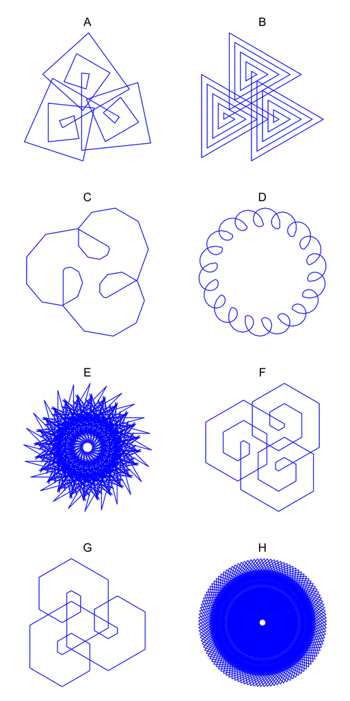

ABCDEFGH

The correct answer is G.

Below I've listed the parameters used to generate all patterns:

- A:
  - Turn angle = 96
  - Count max = 10

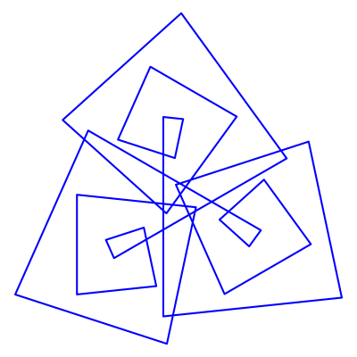

- B:
  - Turn angle = 120
  - Count max = 14

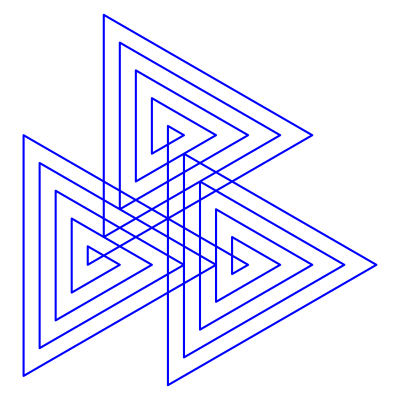

- C:
  - Turn angle = 40
  - Count max = 12

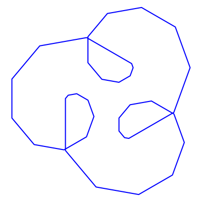

- D:
  - Turn angle = 20
  - Count max = 19

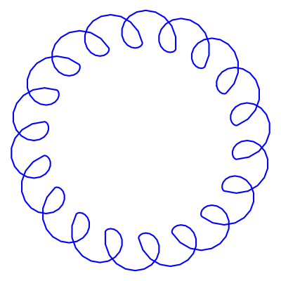

- E:
  - Turn angle = 165
  - Count max = 19

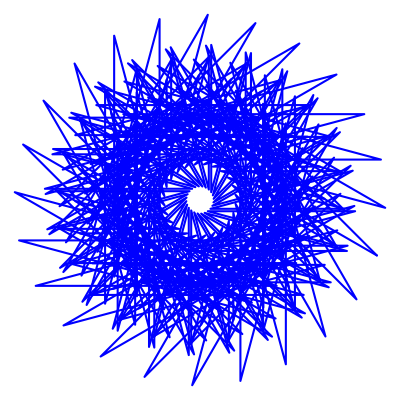

- F:
  - Turn angle = 60
  - Count max = 14

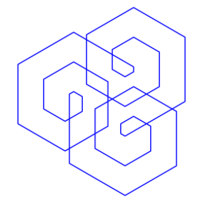

- G:
  - Turn angle = 60
  - Count max = 10

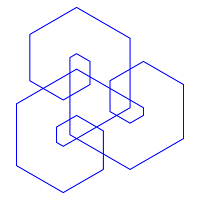

- H:
  - Turn angle = 111
  - Count max = 17

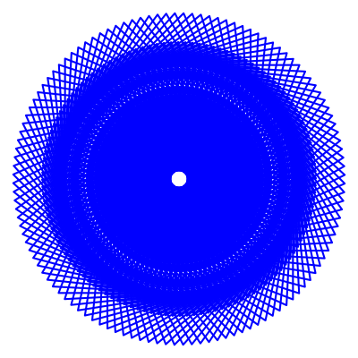

Let's say you want to make a [spirolateral](https://en.wikipedia.org/wiki/Spirolateral).

If the turn angle is $\theta=150^{\circ}$ and the maximum segment length is $n=20$, then which spirolateral is created?

You can use this tool:

https://artockthedino.github.io/pbl/spirolateral/spirolateral_generator.html

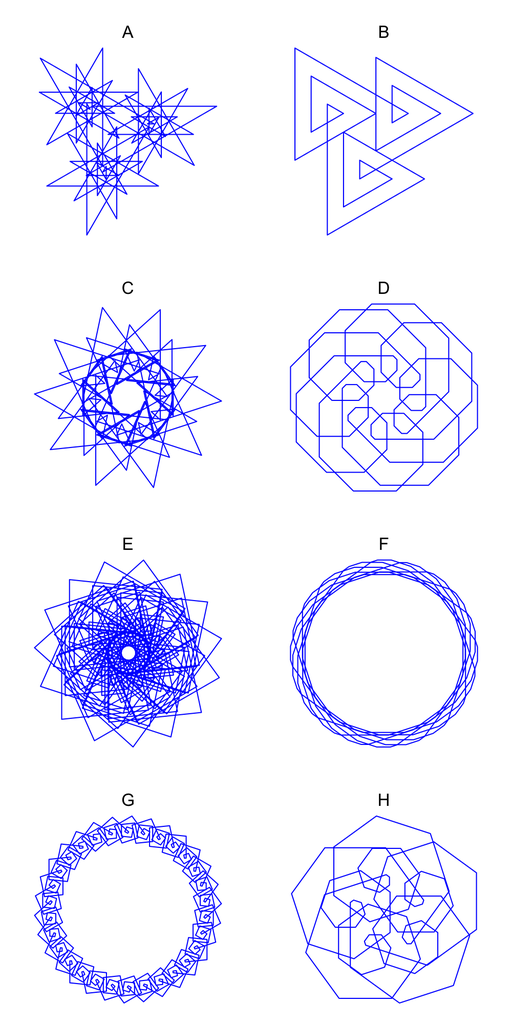

ABCDEFGH

The correct answer is A.

Below I've listed the parameters used to generate all patterns:

- A:
  - Turn angle = 150
  - Count max = 20

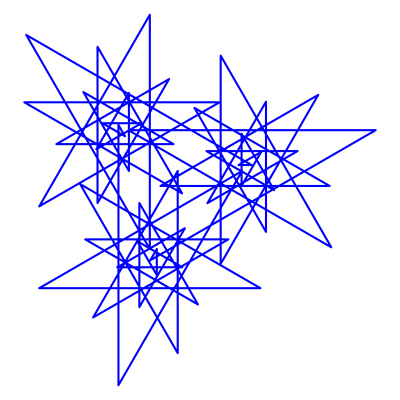

- B:
  - Turn angle = 120
  - Count max = 7

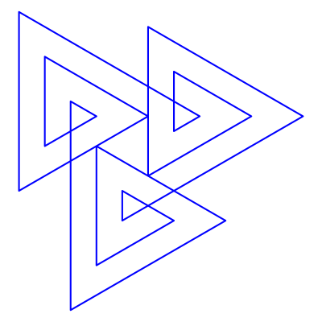

- C:
  - Turn angle = 132
  - Count max = 9

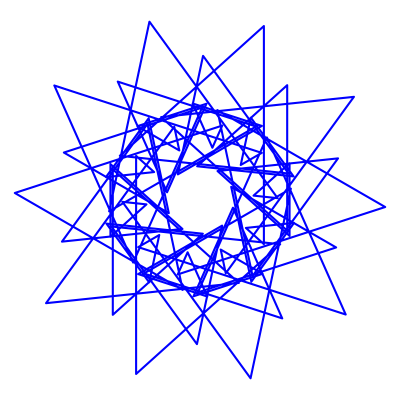

- D:
  - Turn angle = 45
  - Count max = 11

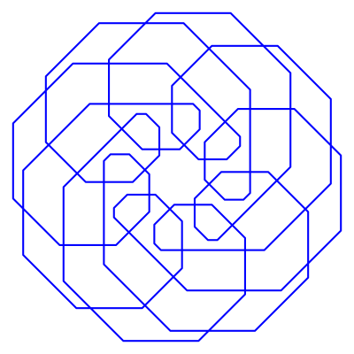

- E:
  - Turn angle = 96
  - Count max = 17

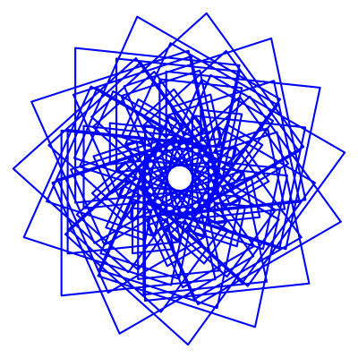

- F:
  - Turn angle = 18
  - Count max = 7

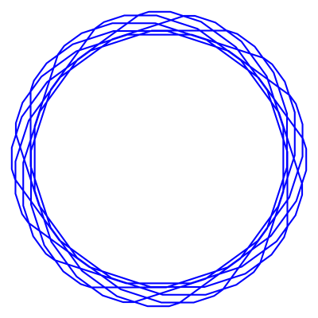

- G:
  - Turn angle = 84
  - Count max = 13

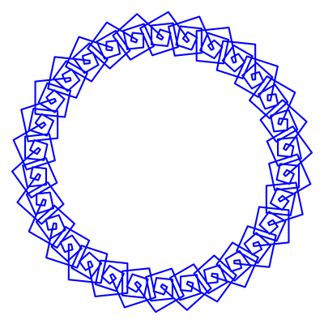

- H:
  - Turn angle = 54
  - Count max = 16

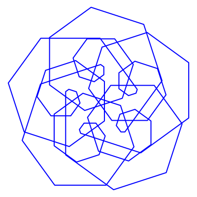

Let's say you want to make a [spirolateral](https://en.wikipedia.org/wiki/Spirolateral).

If the turn angle is $\theta=90^{\circ}$ and the maximum segment length is $n=11$, then which spirolateral is created?

You can use this tool:

https://artockthedino.github.io/pbl/spirolateral/spirolateral_generator.html

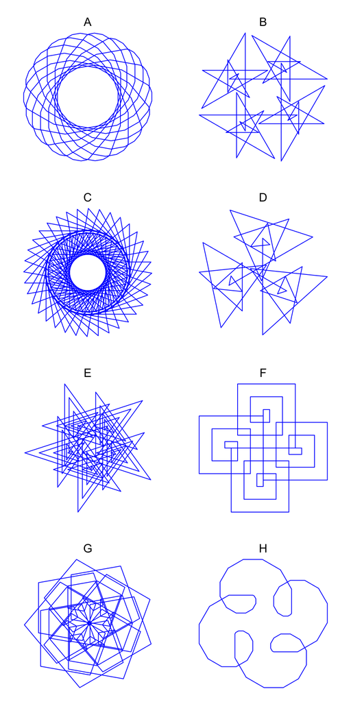

ABCDEFGH

The correct answer is F.

Below I've listed the parameters used to generate all patterns:

- A:
  - Turn angle = 20
  - Count max = 11

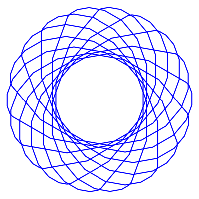

- B:
  - Turn angle = 150
  - Count max = 9

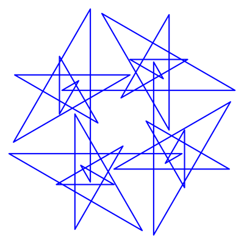

- C:
  - Turn angle = 130
  - Count max = 5

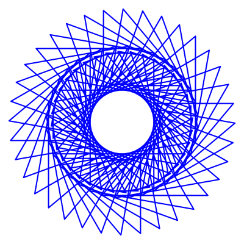

- D:
  - Turn angle = 132
  - Count max = 10

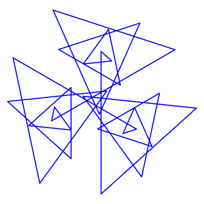

- E:
  - Turn angle = 144
  - Count max = 16

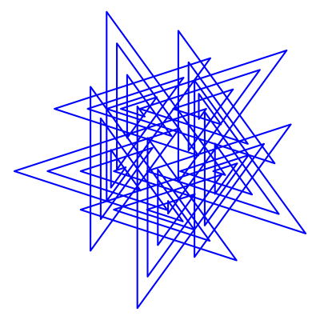

- F:
  - Turn angle = 90
  - Count max = 11

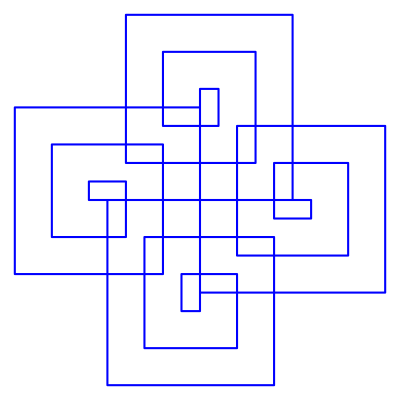

- G:
  - Turn angle = 80
  - Count max = 11

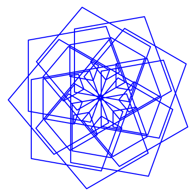

- H:
  - Turn angle = 30
  - Count max = 15

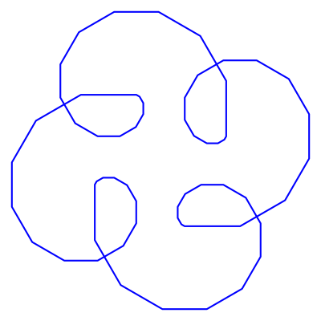

Let's say you want to make a [spirolateral](https://en.wikipedia.org/wiki/Spirolateral).

If the turn angle is $\theta=135^{\circ}$ and the maximum segment length is $n=10$, then which spirolateral is created?